# Tuto barplot - ggplot2

Laurent Cauquil

2022-05-19

# **Packages et rappels**

## Packages

```r
## data
library(palmerpenguins)

## data management
library(dplyr)
##
## Attachement du package : 'dplyr'
## Les objets suivants sont masqués depuis 'package:stats':
##
##     filter, lag
## Les objets suivants sont masqués depuis 'package:base':
##
##     intersect, setdiff, setequal, union
library(tidyr)

## graphics
library(ggplot2)
library(ggsignif)
```

> Rappel:  
> **Raccourcis pour obtenir le pipe: `Ctrl + Alt + M`**  
> - |> si pipe natif de R activé (Tools - Global Options - Code)  
> - sinon %>% pipe de magrittr (repris par dplyr)

## Rappel pour construire un barplot avec le package ggplot2

### Structure minimale

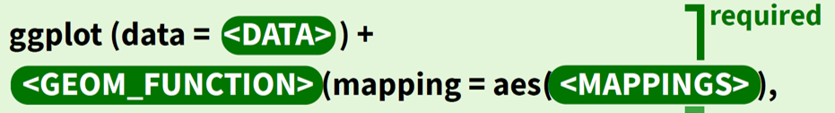

https://raw.githubusercontent.com/rstudio/cheatsheets/main/data-visualization.pdf

DATA = data.frame  
GEOM_FUNCTION = type de graph  
MAPPINGS = association axes/variables

### **`geom_bar()` ou `geom_col()`**

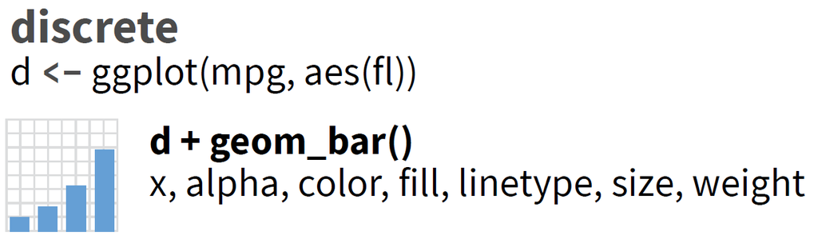

https://raw.githubusercontent.com/rstudio/cheatsheets/main/data-visualization.pdf

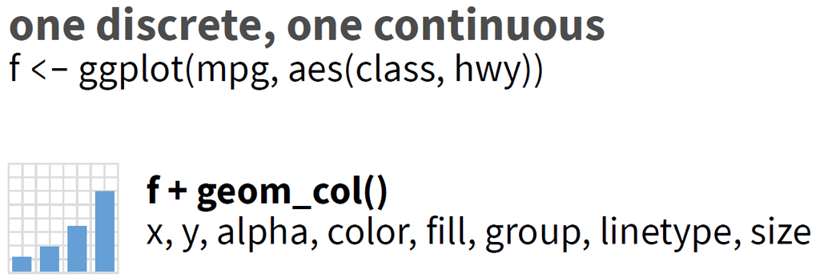

https://raw.githubusercontent.com/rstudio/cheatsheets/main/data-visualization.pdf

# **geom_bar()**

### Plot de base sur la variable discrete `island` du jeu de données `penguins`

#### Synthaxe de la cheatsheet

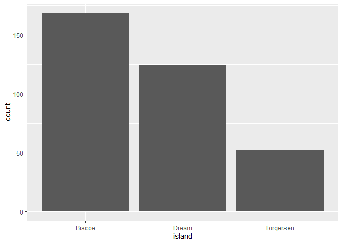

```r
ggplot(data = penguins) +
  geom_bar(mapping = aes(x = island))
```

#### Synthaxe la plus utilisée

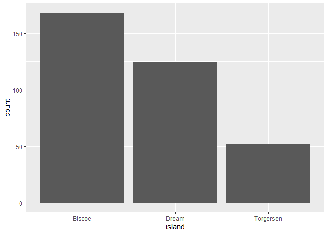

```r
penguins |>
  ggplot(aes(x = island)) +
  geom_bar()
```

#### Barplot horizontal en inversant les axes x <-> y

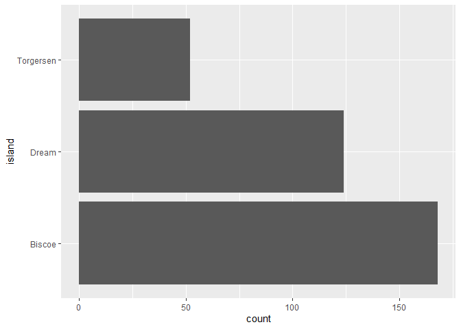

```r
penguins |>
  ggplot(aes(y = island)) +
  geom_bar()
```

#### En mappant directement dans le geom, on peut ajouter d’autres variables à la suite

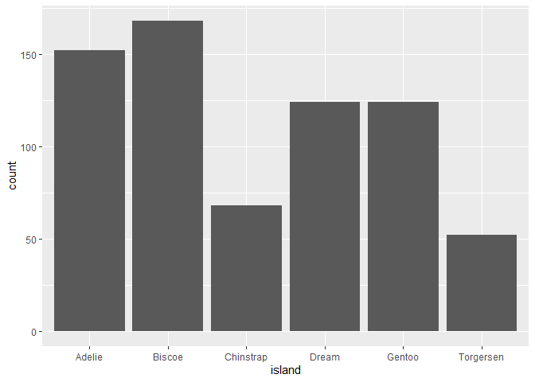

```r
penguins |>
  ggplot() +
  geom_bar(aes(x = island)) +
  geom_bar(aes(x = species))
```

> Sur l’axe des y est reporté l’effectif de chaque niveau (level) de la variable mappée

#### Le `geom_bar()` ne s’applique pas aux variables continues

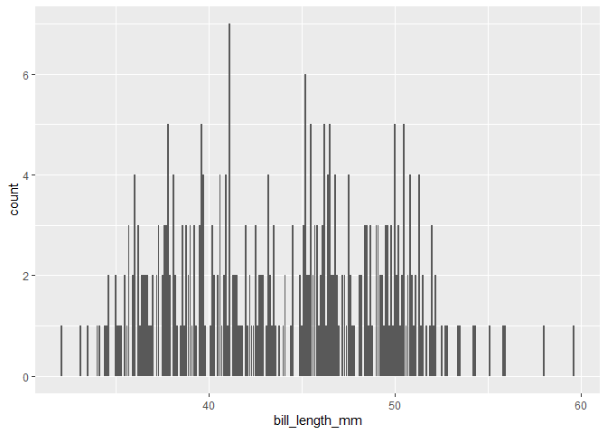

```r
penguins |>
  ggplot(aes(x = bill_length_mm )) +
  geom_bar()
```

> ggplot élimine les NA’s

#### Il faut utiliser un histogramme

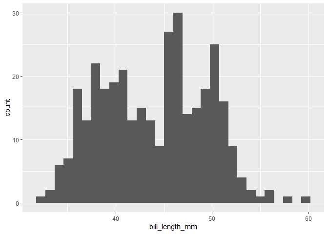

```r
penguins |>
  ggplot(aes(x = bill_length_mm)) +
  geom_histogram()
```

### Mappings 2 variables ou plus

#### Ajout de la couleur

> Attention 2 paramètres pour appliquer des couleurs:  
> - color pour les bordures des barres  
> - fill (remplir) pour l’intérieur des barres

ggplot ajoute automatiquement la légende

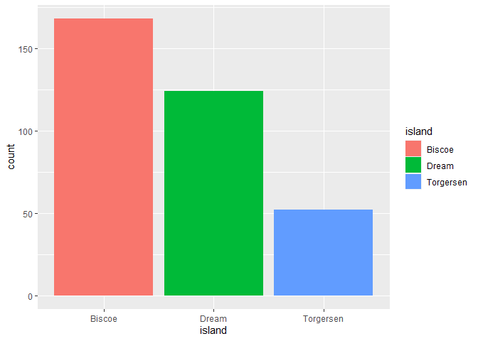

```r
penguins |>
  ggplot(aes(x = island,
             fill = island)) +
  geom_bar()
```

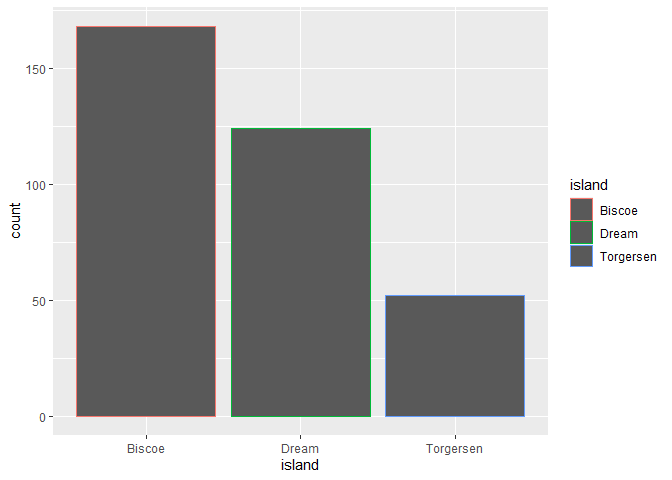

```r
penguins |>
  ggplot(aes(x = island,
             color = island)) +
  geom_bar()
```

#### On peut utiliser la couleur pour visualiser une deuxième variable discrete

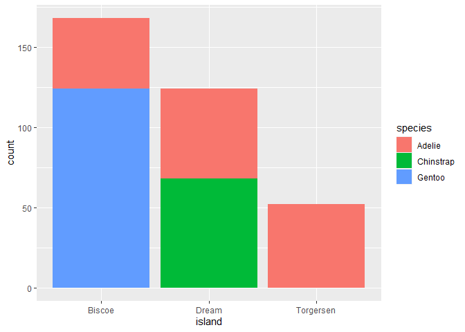

```r
penguins |>
ggplot(aes(x = island,
           fill = species)) +
  geom_bar()
```

# **Faceting**

#### Le faceting permet de rajouter encore une troisième discrete en répartissant les graphes associés à chaque level dans un panneau différent

**2 functions:**

- `facet_wrap()`
- `facet_grid()`

**2 modes d’affichages différents**

- `facet_wrap()` affiche les panneaux les uns à la suite des autres dans un cadre donné
- `facet_grip()` affiche les panneaux sur une grille définie par les différents niveaux

**Utilisation**

- `facet_wrap()` pour une variable
- `facet_grip()` pour la combinaison de 2 variables

**Paramètres d’affichage**

- `facet_wrap()` ncol, nrow: cadre dans lequel sont affichés les panneaux (remplissage par ligne, comme un vecteur dans une matrice)
- `facet_grip()` cols, rows: association des variables aux lignes et colonnes

> Remarques:  
> facet_grid peut afficher des panneaux vides si la combinaison n’a pas de graph  
> Si facet_wrap avec combinaisons de 2 variables (var1 ~ var2), les combinaisons vides ne seront pas affichées

#### Facet_wrap()

**Faceting par le sexe**

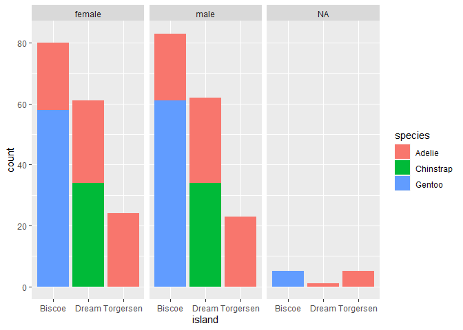

```r
penguins |>
  ggplot(aes(x = island,
             fill = species)) +
  geom_bar() +
  facet_wrap(vars(sex))
```

**Faceting par le sexe sur 3 lignes**

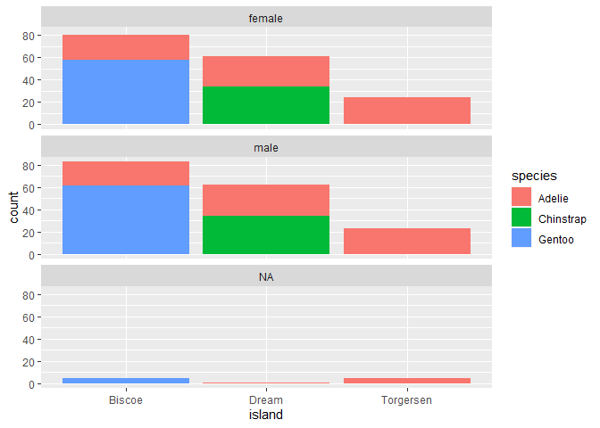

```r
penguins |>
  ggplot(aes(x = island,
             fill = species)) +
  geom_bar() +
  facet_wrap(vars(sex), nrow = 3)
```

**Faceting par les iles et l’espèce sur 2 lignes**

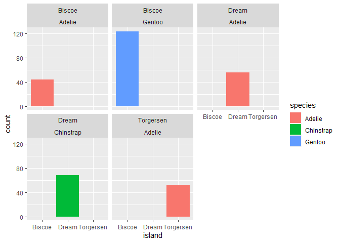

```r
penguins |>
  ggplot(aes(x = island,
             fill = species)) +
  geom_bar() +
  facet_wrap(island ~ species, nrow = 2)
```

#### Facet_grid()

**Faceting par le sexe**

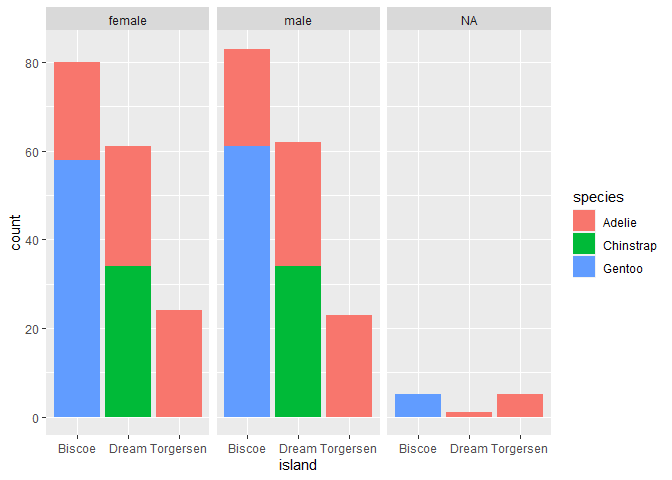

```r
penguins |>
  ggplot(aes(x = island,
             fill = species)) +
  geom_bar() +
  facet_grid(cols = vars(sex))
```

**Faceting par le sexe en ligne**

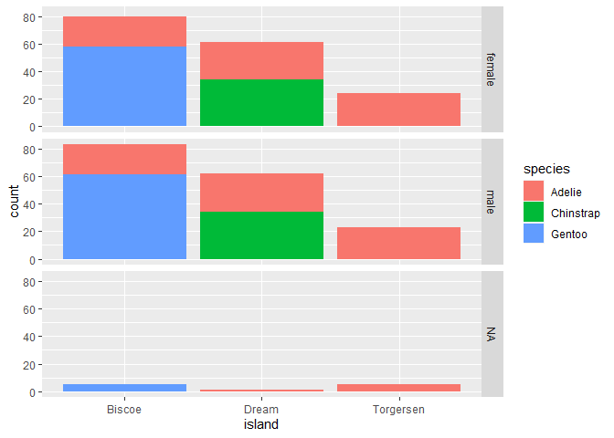

```r
penguins |>
  ggplot(aes(x = island,
             fill = species)) +
  geom_bar() +
  facet_grid(rows = vars(sex))
```

**Faceting par les iles et l’espèce**

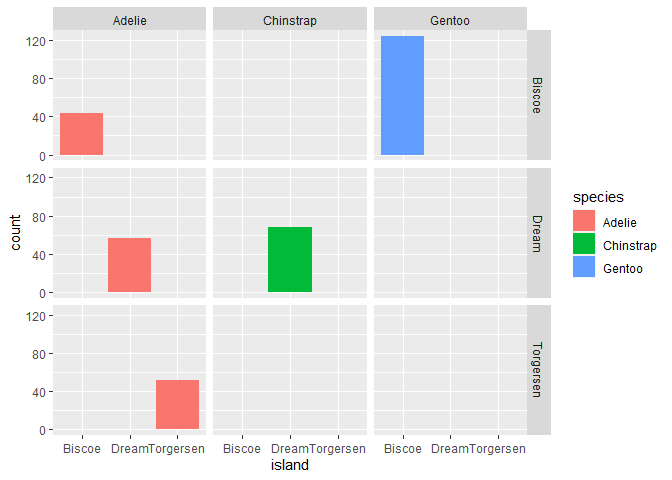

```r
penguins |>
  ggplot(aes(x = island,
             fill = species)) +
  geom_bar() +
  facet_grid(rows = vars(island),
             cols = vars(species))
```

### 3 mode d’affichage des barres quand 2 variables

#### Mode dodge (côte-à-côte)

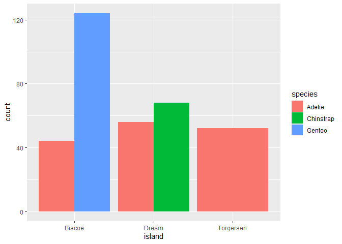

```r
penguins |>
  ggplot(aes(x = island,
             fill = species)) +
  geom_bar(position = "dodge")
```

#### Mode stack (empilé)

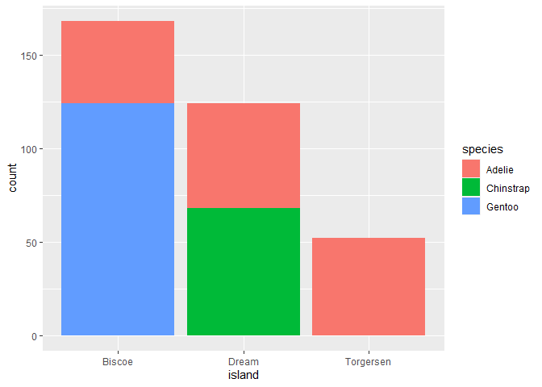

```r
penguins |>
  ggplot(aes(x = island,
             fill = species)) +
  geom_bar(position = "stack")
```

#### Mode fill (normalisé à 1)

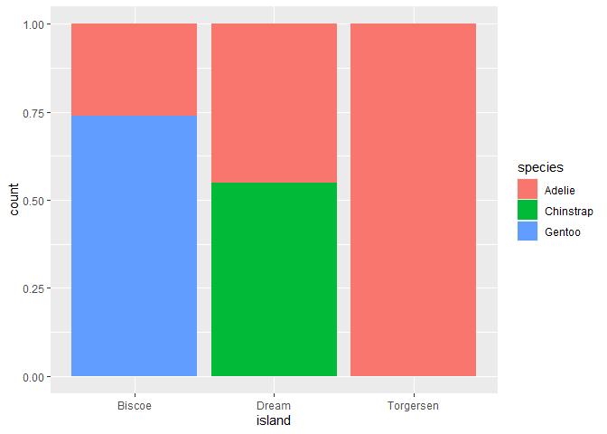

```r
penguins |>
  ggplot(aes(x = island,
             fill = species)) +
  geom_bar(position = "fill")
```

# **geom_col()**

### Plot de base sur la variable continue `body_mass_g`

#### La fonction `ggplot()` prépare les axes en fonction des variables associées (mapped) dans `aes()`

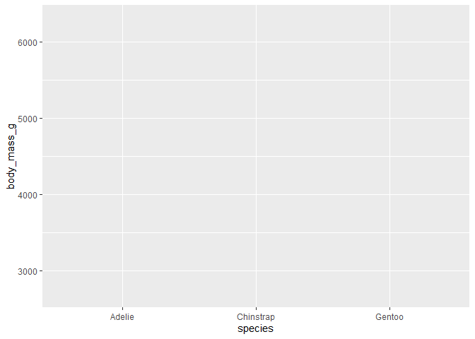

```r
penguins |>
  ggplot(aes(x = species,
             y = body_mass_g))
```

#### Rajout de la couche `geom_col()`

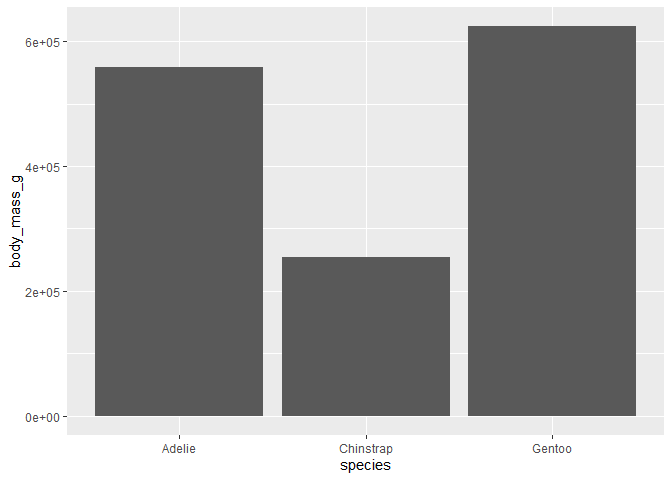

```r
penguins |>
  ggplot(aes(x = species,
             y = body_mass_g)) +
  geom_col()
```

#### Rajout de la couleur avec la légende

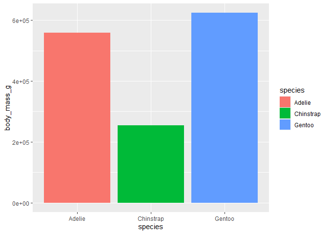

```r
penguins |>
  ggplot(aes(x = species,
             y = body_mass_g,
             fill = species)) +
  geom_col()
```

#### Afficher la moyenne des poids par espèce

> Attention il y a des NA’s  
> Ne pas oublier de rajouter `na.rm = T` au calul de la moyenne

```r
penguins |>
  group_by(species) |>
  summarise(mean = mean(body_mass_g, na.rm = T))
```

```
## # A tibble: 3 × 2
##   species    mean
##   <fct>     <dbl>
## 1 Adelie    3701.
## 2 Chinstrap 3733.
## 3 Gentoo    5076.
```

ggplot prend en entrée un data.frame résultat du calcul des moyennes

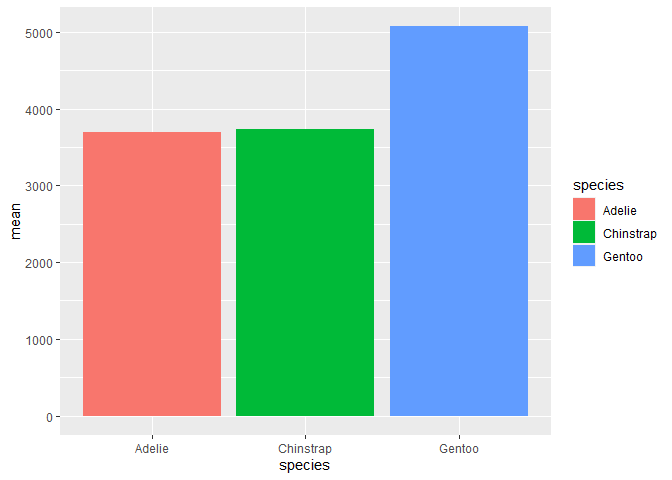

```r
penguins |>
  group_by(species) |>
  summarise(mean = mean(body_mass_g, na.rm = T)) |>
  ggplot(aes(x = species,
             y = mean,
             fill = species)) +
  geom_col()
```

#### Affiche la moyenne des poids par espèce et par ile

> Attention: ne pas oublier d’inclure la variable `island` dans le `group_by` pour le calcul des moyennes

> Utiliser la position “dodge” pour une meilleure lisibilité sur l’axe des y

```r
penguins |>
  group_by(species, island) |>
  summarise(mean = mean(body_mass_g, na.rm = T))
```

```
## # A tibble: 5 × 3
## # Groups:   species [3]
##   species   island     mean
##   <fct>     <fct>     <dbl>
## 1 Adelie    Biscoe    3710.
## 2 Adelie    Dream     3688.
## 3 Adelie    Torgersen 3706.
## 4 Chinstrap Dream     3733.
## 5 Gentoo    Biscoe    5076.
```

```r
penguins |>
  group_by(species, island) |>
  summarise(mean = mean(body_mass_g, na.rm = T)) |>
  ggplot(aes(x = species,
             y = mean,
             fill = island)) +
  geom_col(position = "dodge")
```

[output not shown]

#### Faceting par le sexe

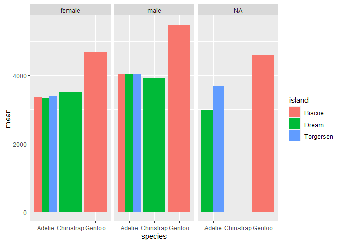

```r
penguins |>
  group_by(species, island, sex) |>
  summarise(mean = mean(body_mass_g, na.rm = T)) |>
  ggplot(aes(x = species,
             y = mean,
             fill = island)) +
  geom_col(position = "dodge") +
  facet_grid(cols = vars(sex))
```

# **Customisation**

Il y a 3 familles de fonctions:

- `scale_xx_xxx()`: customisation en fonction des données
- `theme()`: customisation générale de tous les graphes d’un projet
- `labs()`: customisation générale d’un graphe

> Néanmoins il peut y avoir plusieurs méthodes pour modifier un élément d’un graph  
> En choisir une et s’y tenir pour une meilleure lisibilité et éviter les confusions

## **`geom_bar()`**

### Changer l’ordre des niveaux sur l’axe des x et dans la légende

**Graphe de départ**

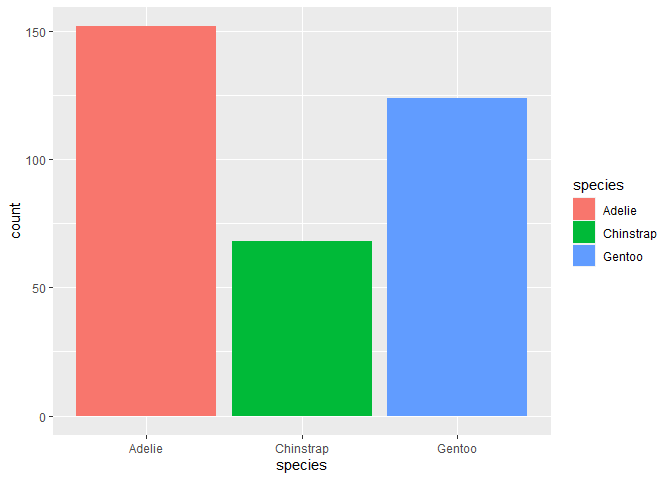

```r
penguins |>
  ggplot(aes(x = species,
             fill = species)) +
  geom_bar()
```

**Changer l’ordre des niveaux directement**

> le titre de l’axe des x est changé

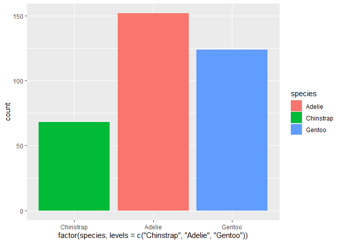

```r
penguins |>
  ggplot(aes(x = factor(species, levels = c("Chinstrap", "Adelie", "Gentoo")),
             fill = species)) +
  geom_bar()
```

**Changer l’ordre des niveaux avec un objet**

> le titre de l’axe des x prend le nom de l’objet

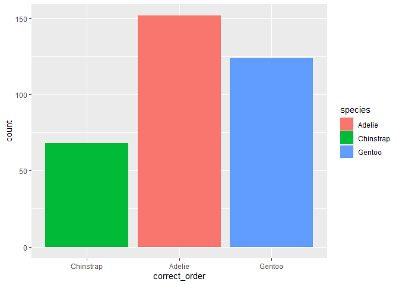

```r
correct_order <- factor(penguins$species, levels = c("Chinstrap", "Adelie", "Gentoo"))
penguins |>
  ggplot(aes(x = correct_order,
             fill = species)) +
  geom_bar()
```

**Même méthode pour la légende**

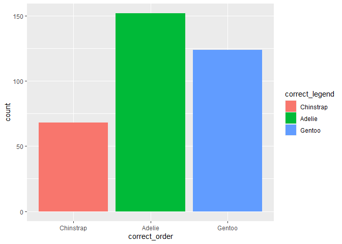

```r
correct_legend <- factor(penguins$species, levels = c("Chinstrap", "Adelie", "Gentoo"))
penguins |>
  ggplot(aes(x = correct_order,
             fill = correct_legend)) +
  geom_bar()
```

### Changer les couleurs

Il faut tout d’abord associer à chaque niveau une couleur.

**Nouvelles couleurs pour les espèces**

```r
correct_col <- c("Chinstrap" = "dodgerblue3",
                 "Adelie" = "purple",
                 "Gentoo" = "yellowgreen")
```

Utiliser la fonction `scale_fill_manual()` une fois le graphe construit.

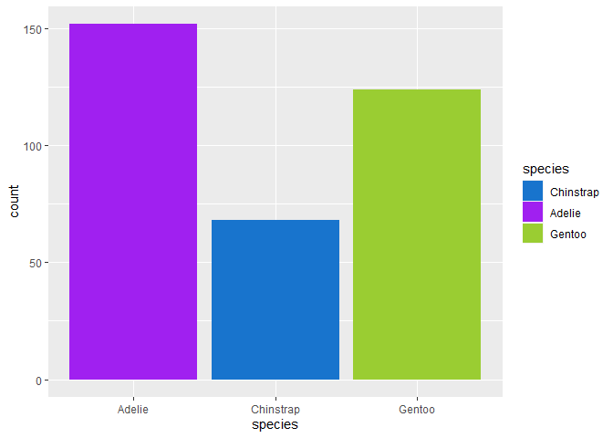

```r
penguins |>
  ggplot(aes(x = species,
             fill = species)) +
  geom_bar() +
  scale_fill_manual(values = correct_col)
```

> Attention: l’ordre des affectations dans l’objet `correct_col` détermine l’ordre dans la légende !

## **`geom_col()`**

### Changer l’ordre des niveaux sur l’axe des x et dans la légende (cas simple analogue à `geom_bar()`)

Dans une utilisation simple de `geom_col()`, c’est la même méthode que pour `geom_bar()`.

**Graphe de base**

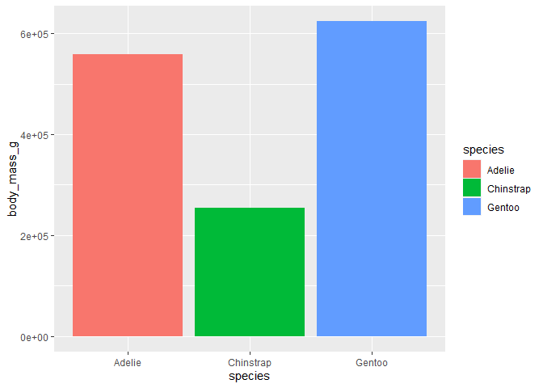

```r
penguins |>
  ggplot(aes(x = species,
             y = body_mass_g,
             fill = species)) +
  geom_col()
```

**Changer l’ordre des niveaux directement**

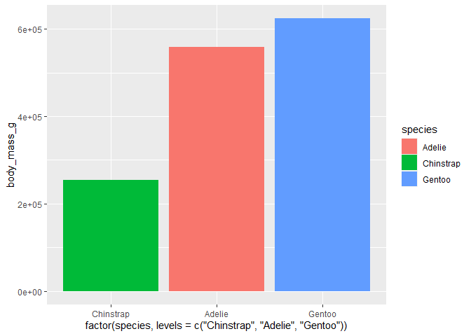

```r
penguins |>
  ggplot(aes(x = factor(species, levels = c("Chinstrap", "Adelie", "Gentoo")),
             y = body_mass_g,
             fill = species)) +
  geom_col()
```

**Changer l’ordre des niveaux avec un objet**

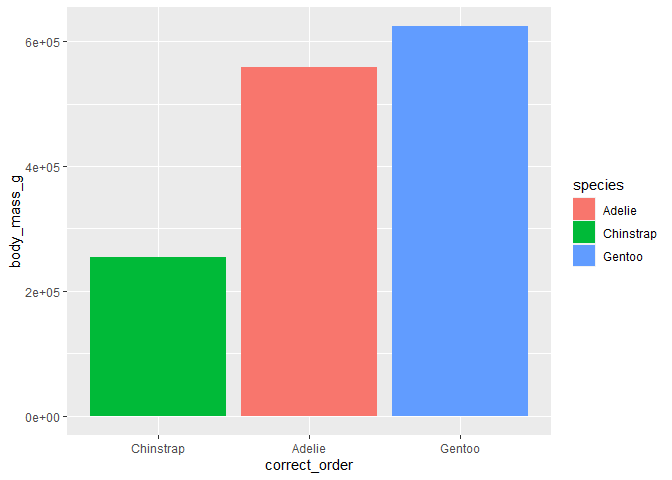

```r
correct_order <- factor(penguins$species, levels = c("Chinstrap", "Adelie", "Gentoo"))
penguins |>
  ggplot(aes(x = correct_order,
             y = body_mass_g,
             fill = species)) +
  geom_col()
```

### Changer l’ordre des niveaux sur l’axe des x et dans la légende (cas plus complexe avec création d’une variable)

Dans un soucis de clarté on calcule les moyennes des poids pour chaque espèce

**Calcul des moyennes des poids**

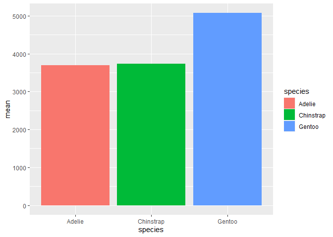

```r
penguins |>
  group_by(species) |>
  summarise(mean = mean(body_mass_g, na.rm = T)) |>
  ggplot(aes(x = species,
             y = mean,
             fill = species)) +
  geom_col()
```

**Changer l’ordre des niveaux directement**

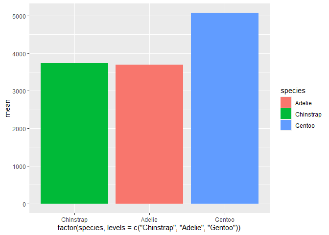

```r
penguins |>
  group_by(species) |>
  summarise(mean = mean(body_mass_g, na.rm = T)) |>
  ggplot(aes(x = factor(species, levels = c("Chinstrap", "Adelie", "Gentoo")),
             y = mean,
             fill = species)) +
  geom_col()
```

**Changer l’ordre des niveaux avec un objet**

```r
correct_order <- factor(penguins$species, levels = c("Chinstrap", "Adelie", "Gentoo"))
penguins |>
  group_by(species) |>
  summarise(mean = mean(body_mass_g, na.rm = T)) |>
  ggplot(aes(x = correct_order,
             y = mean,
             fill = species)) +
  geom_col()
```

> MARCHE PAS !!!

> `correct_order` est construit à partir de `penguins` alors que le graphe est construit à partir du résultat du `summarise()` !

```r
correct_order
##   [1] Adelie    Adelie    Adelie    Adelie    Adelie    Adelie    Adelie
##   [8] Adelie    Adelie    Adelie    Adelie    Adelie    Adelie    Adelie
##  [15] Adelie    Adelie    Adelie    Adelie    Adelie    Adelie    Adelie
##  [22] Adelie    Adelie    Adelie    Adelie    Adelie    Adelie    Adelie
##  [29] Adelie    Adelie    Adelie    Adelie    Adelie    Adelie    Adelie
##  [36] Adelie    Adelie    Adelie    Adelie    Adelie    Adelie    Adelie
##  [43] Adelie    Adelie    Adelie    Adelie    Adelie    Adelie    Adelie
##  [50] Adelie    Adelie    Adelie    Adelie    Adelie    Adelie    Adelie
##  [57] Adelie    Adelie    Adelie    Adelie    Adelie    Adelie    Adelie
##  [64] Adelie    Adelie    Adelie    Adelie    Adelie    Adelie    Adelie
##  [71] Adelie    Adelie    Adelie    Adelie    Adelie    Adelie    Adelie
##  [78] Adelie    Adelie    Adelie    Adelie    Adelie    Adelie    Adelie
##  [85] Adelie    Adelie    Adelie    Adelie    Adelie    Adelie    Adelie
##  [92] Adelie    Adelie    Adelie    Adelie    Adelie    Adelie    Adelie
##  [99] Adelie    Adelie    Adelie    Adelie    Adelie    Adelie    Adelie
## [106] Adelie    Adelie    Adelie    Adelie    Adelie    Adelie    Adelie
## [113] Adelie    Adelie    Adelie    Adelie    Adelie    Adelie    Adelie
## [120] Adelie    Adelie    Adelie    Adelie    Adelie    Adelie    Adelie
## [127] Adelie    Adelie    Adelie    Adelie    Adelie    Adelie    Adelie
## [134] Adelie    Adelie    Adelie    Adelie    Adelie    Adelie    Adelie
## [141] Adelie    Adelie    Adelie    Adelie    Adelie    Adelie    Adelie
## [148] Adelie    Adelie    Adelie    Adelie    Adelie    Gentoo    Gentoo
## [155] Gentoo    Gentoo    Gentoo    Gentoo    Gentoo    Gentoo    Gentoo
## [162] Gentoo    Gentoo    Gentoo    Gentoo    Gentoo    Gentoo    Gentoo
## [169] Gentoo    Gentoo    Gentoo    Gentoo    Gentoo    Gentoo    Gentoo
## [176] Gentoo    Gentoo    Gentoo    Gentoo    Gentoo    Gentoo    Gentoo
## [183] Gentoo    Gentoo    Gentoo    Gentoo    Gentoo    Gentoo    Gentoo
## [190] Gentoo    Gentoo    Gentoo    Gentoo    Gentoo    Gentoo    Gentoo
## [197] Gentoo    Gentoo    Gentoo    Gentoo    Gentoo    Gentoo    Gentoo
## [204] Gentoo    Gentoo    Gentoo    Gentoo    Gentoo    Gentoo    Gentoo
## [211] Gentoo    Gentoo    Gentoo    Gentoo    Gentoo    Gentoo    Gentoo
## [218] Gentoo    Gentoo    Gentoo    Gentoo    Gentoo    Gentoo    Gentoo
## [225] Gentoo    Gentoo    Gentoo    Gentoo    Gentoo    Gentoo    Gentoo
## [232] Gentoo    Gentoo    Gentoo    Gentoo    Gentoo    Gentoo    Gentoo
## [239] Gentoo    Gentoo    Gentoo    Gentoo    Gentoo    Gentoo    Gentoo
## [246] Gentoo    Gentoo    Gentoo    Gentoo    Gentoo    Gentoo    Gentoo
## [253] Gentoo    Gentoo    Gentoo    Gentoo    Gentoo    Gentoo    Gentoo
## [260] Gentoo    Gentoo    Gentoo    Gentoo    Gentoo    Gentoo    Gentoo
## [267] Gentoo    Gentoo    Gentoo    Gentoo    Gentoo    Gentoo    Gentoo
## [274] Gentoo    Gentoo    Gentoo    Chinstrap Chinstrap Chinstrap Chinstrap
## [281] Chinstrap Chinstrap Chinstrap Chinstrap Chinstrap Chinstrap Chinstrap
## [288] Chinstrap Chinstrap Chinstrap Chinstrap Chinstrap Chinstrap Chinstrap
## [295] Chinstrap Chinstrap Chinstrap Chinstrap Chinstrap Chinstrap Chinstrap
## [302] Chinstrap Chinstrap Chinstrap Chinstrap Chinstrap Chinstrap Chinstrap
## [309] Chinstrap Chinstrap Chinstrap Chinstrap Chinstrap Chinstrap Chinstrap
## [316] Chinstrap Chinstrap Chinstrap Chinstrap Chinstrap Chinstrap Chinstrap
## [323] Chinstrap Chinstrap Chinstrap Chinstrap Chinstrap Chinstrap Chinstrap
## [330] Chinstrap Chinstrap Chinstrap Chinstrap Chinstrap Chinstrap Chinstrap
## [337] Chinstrap Chinstrap Chinstrap Chinstrap Chinstrap Chinstrap Chinstrap
## [344] Chinstrap
## Levels: Chinstrap Adelie Gentoo
penguins |>
  group_by(species) |>
  summarise(mean = mean(body_mass_g, na.rm = T))
## # A tibble: 3 × 2
##   species    mean
##   <fct>     <dbl>
## 1 Adelie    3701.
## 2 Chinstrap 3733.
## 3 Gentoo    5076.
```

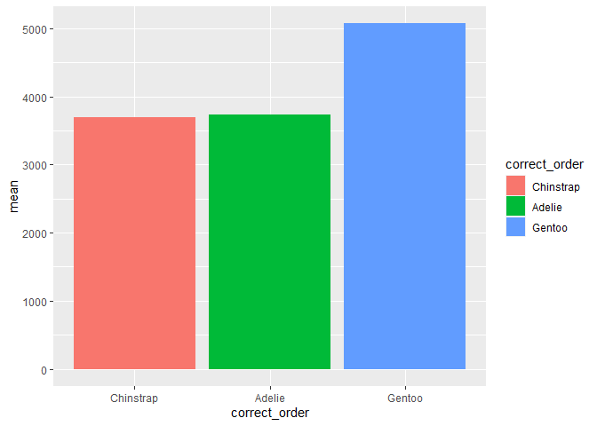

```r
correct_order <- factor(c("Chinstrap", "Adelie", "Gentoo"), levels = c("Chinstrap", "Adelie", "Gentoo"))
penguins |>
  group_by(species) |>
  summarise(mean = mean(body_mass_g, na.rm = T)) |>
  ggplot(aes(x = correct_order,
             y = mean,
             fill = correct_order)) +
  geom_col()
```

**Modifier les couleurs**

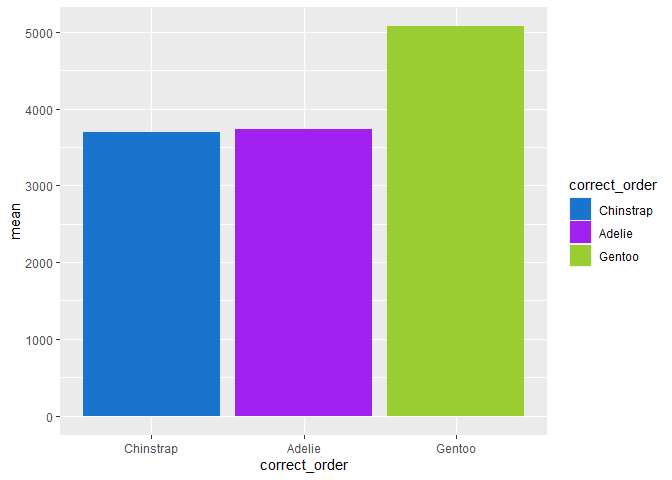

```r
correct_order <- factor(c("Chinstrap", "Adelie", "Gentoo"), levels = c("Chinstrap", "Adelie", "Gentoo"))
correct_col <- c("Chinstrap" = "dodgerblue3",
                 "Adelie" = "purple",
                 "Gentoo" = "yellowgreen")
penguins |>
  group_by(species) |>
  summarise(mean = mean(body_mass_g, na.rm = T)) |>
  ggplot(aes(x = correct_order,
             y = mean,
             fill = correct_order)) +
  geom_col() +
  scale_fill_manual(values = correct_col)
```

> Attention: cela devient trés complexe voire impossible si on rajoute d’autres calculs  
> Préparer en amont le data.frame utilisé pour le graph en utilisant la fonction mutate pour créer de nouvelles variables (mean, sd, …)

## Customisation avec la fonction `scale()` -> spécifique d’un graph

### Barplot avec 2 variables discretes

```r
penguins |>
  group_by(species, island) |>
  mutate(mean = mean(body_mass_g, na.rm = T)) -> df

df |>
  ggplot(aes(x = species,
             y = mean,
             fill = island)) +
  geom_col(position = "dodge") -> p
p
```

**Change les titres des axes**

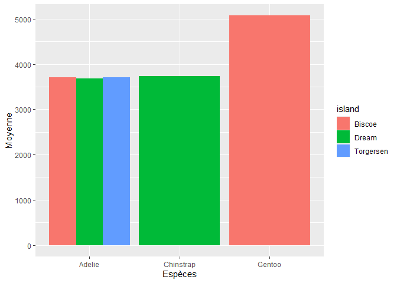

```r
p +
  scale_x_discrete(name = "Espèces") +
  scale_y_continuous(name = "Moyenne")
```

**Change l’ordre des couleurs sur l’axe des x**

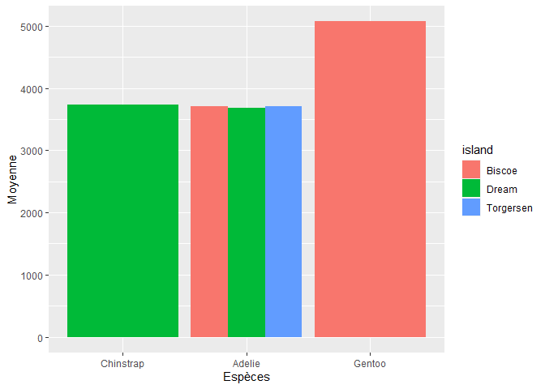

```r
p +
  scale_x_discrete(name = "Espèces",
                   limits = c("Chinstrap", "Adelie", "Gentoo")) +
  scale_y_continuous(name = "Moyenne") +
  scale_colour_manual(labels = c("Dream", "Biscoe", "Torgersen"))
```

**Change l’ordre des couleurs sur l’axe des x et dans la légende**

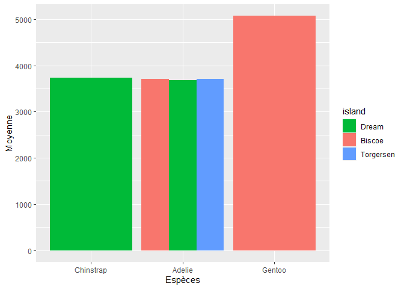

```r
p +
  scale_x_discrete(name = "Espèces",
                   limits = c("Chinstrap", "Adelie", "Gentoo")) +
  scale_y_continuous(name = "Moyenne") +
  scale_colour_manual(labels = c("Dream", "Biscoe", "Torgersen")) +
  scale_fill_discrete(breaks = c("Dream", "Biscoe", "Torgersen"))
```

**Change l’ordre des couleurs sur l’axe des x et dans la légende, titre de la légende**

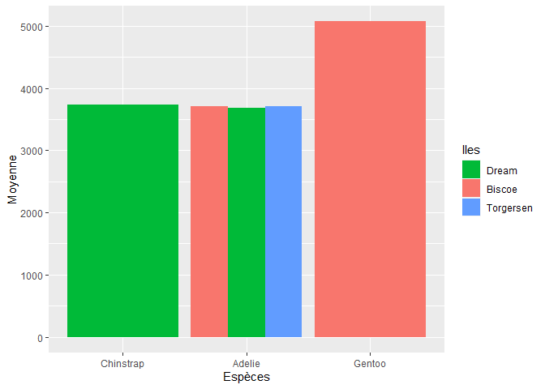

```r
p +
  scale_x_discrete(name = "Espèces",
                   limits = c("Chinstrap", "Adelie", "Gentoo")) +
  scale_y_continuous(name = "Moyenne") +
  scale_colour_manual(labels = c("Dream", "Biscoe", "Torgersen")) +
  scale_fill_discrete("Iles", breaks = c("Dream", "Biscoe", "Torgersen"))
```

## Customisation avec la fonction `labs()` -> non spécifique aux données d’un graph

```r
penguins |>
  group_by(species, island) |>
  mutate(mean = mean(body_mass_g, na.rm = T)) -> df

df |>
  ggplot(aes(x = species,
             y = mean,
             fill = island)) +
  geom_col(position = "dodge") -> p
p
```

`labs()`:

- Titre
- Sous-titre
- Titre des axes
- Identifiant de la figure (`caption`)
- Etiquette “A” (`tag`)

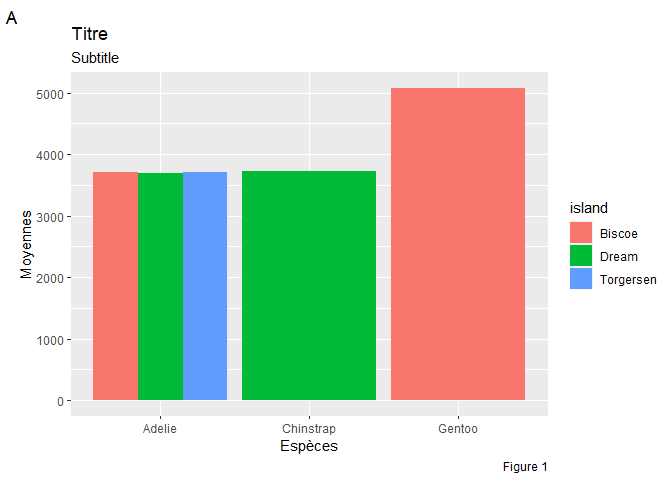

```r
p +
  labs(title = "Titre",
       subtitle = "Subtitle",
       x = "Espèces",
       y = "Moyennes",
       caption = "Figure 1",
       tag = "A")
```

## Customisation avec la fonction `theme()` -> commun à plusieurs graphes (?theme)

> Concerne l’aspect général (polices, tailles, couleurs…) de tous les attributs d’un graphe
- Axes `axis`
- Légendes `legend`
- Cadre et grille du graph `panel`, `plot`
- les paramètres de `labs`
- Panneau des facets `strip`

### Spécifier les attributs avec `element_` (?element_text)

- `element_rect()`: cadre et arrière-plan
- `element_line()`: lignes
- `element_text()`: textes

### theme(plot.)

```r
p
```

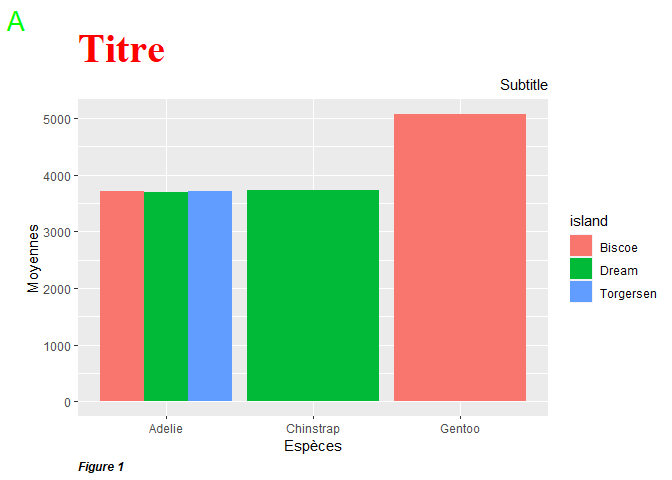

```r
p +
  labs(title = "Titre",
       subtitle = "Subtitle",
       x = "Espèces",
       y = "Moyennes",
       caption = "Figure 1",
       tag = "A") +
  theme(plot.title = element_text(color = "red",
                                  size = 30,
                                  face = "bold",
                                  family = "serif"),
        plot.subtitle = element_text(hjust = 1),
        plot.caption = element_text(hjust = 0,
                                    face = "bold.italic"),
        plot.tag = element_text(color = "green",
                                size = 20))
```

### theme(axis.)

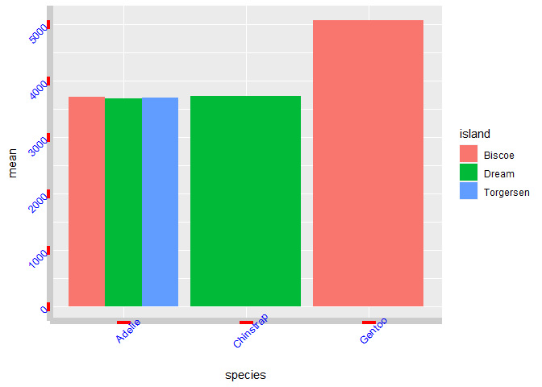

```r
p +
  theme(axis.line = element_line(size = 3,
                                 colour = "grey80"),
        axis.text = element_text(colour = "blue",
                                 angle = 45,
                                 size = 10),
        axis.ticks = element_line(color = "red"),
        axis.ticks.x = element_line(size = 6),
        axis.ticks.y = element_line(size = 4))
```

**Enlever la légende**

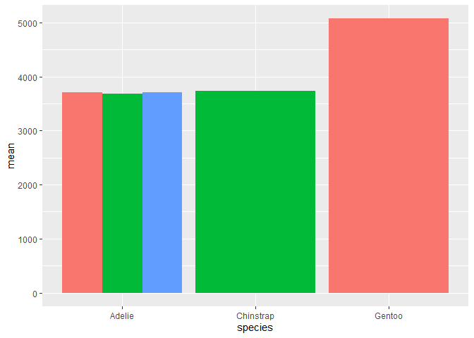

```r
p +
  theme(legend.position = "none")
```

**Légende en bas**

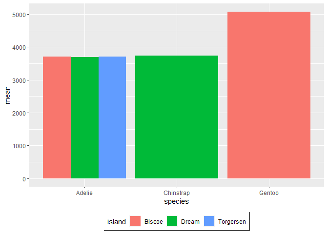

```r
p +
  theme(legend.position = "bottom",
        legend.box.background = element_rect())
```

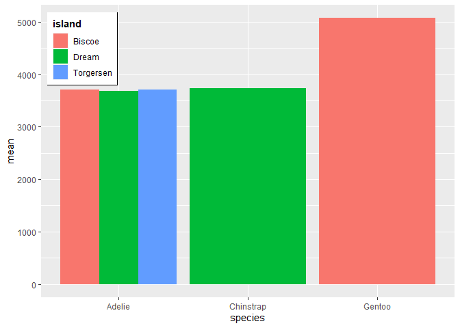

```r
p +
  theme(legend.position = c(.10, .85),
        legend.box.background = element_rect(),
        legend.title = element_text(face = "bold"))
```

### theme(strip.)

**change les titres des panneaux**

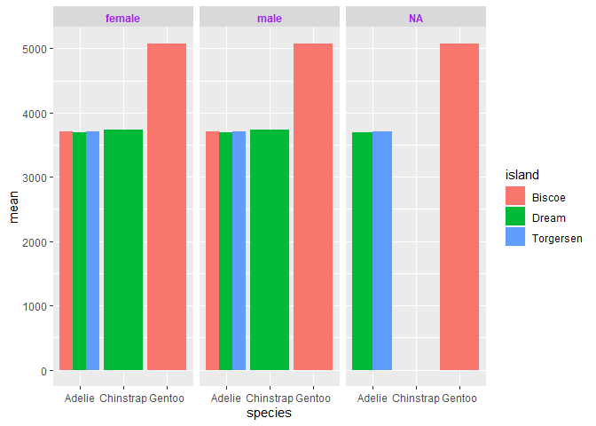

```r
p +
  theme(strip.text.x = element_text(colour = "purple",
                                    face = "bold")) +
  facet_grid(cols = vars(sex))
```

### Police de caractères

Pour utiliser les polices de caractères installées sur son PC. Suivre ce lien pour les détails : (https://r-coder.com/custom-fonts-r/)

```r
library(extrafont)
library(remotes)
install_version("Rttf2pt1", version = "1.3.8")
font_import()
```

```r
library(extrafont)
```

Répondre “y” à la question, attention l’importation dure quelques minutes

La fonction `fonts()` permet d’afficher les différentes polices disponibles.

```r
head(fonts())
```

[output not shown]

Par la suite, il faut charger les polices à chaque ouverte de session R

```r
loadfonts(device = "win")
```

**Exemple avec la police et couleur INRAE**

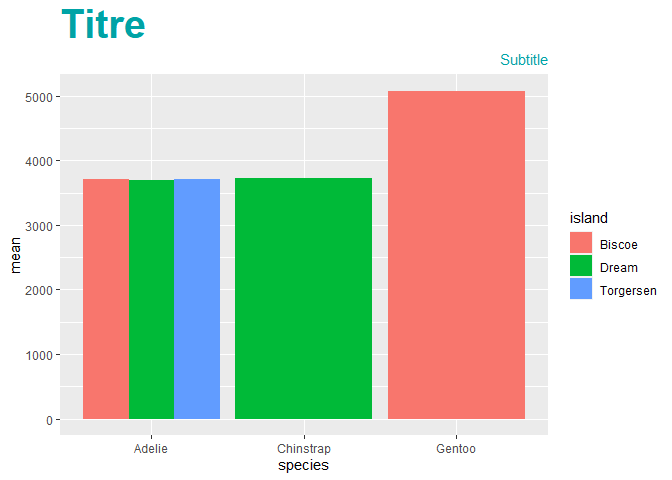

```r
p +
  labs(title = "Titre",
       subtitle = "Subtitle") +
  theme(plot.title = element_text(color = "#00a3a6",
                                  size = 30,
                                  face = "bold",
                                  family = "Raleway"),
        plot.subtitle = element_text(color = "#00a3a6",
                                     hjust = 1,
                                     family = "Raleway"))
```